# Employee Promotion Prediction

We as a Data Scientist at "JMD company" have to analyze the employees' performance data and information to provide recommendations to the HR Team and also build a model to predict the potential employees who is going to be promoted

# Import Libraries

```python
!pip install imblearn

# To enable plotting graphs in Jupyter notebook
%matplotlib inline
```

```python
import pandas as pd
import numpy as np
from sklearn import metrics
import matplotlib.pyplot as plt

%matplotlib inline
import warnings

warnings.filterwarnings("ignore")
import seaborn as sns
from sklearn.model_selection import train_test_split, StratifiedKFold, cross_val_score
from sklearn.model_selection import GridSearchCV
from sklearn import metrics
from sklearn.ensemble import BaggingClassifier, RandomForestClassifier
from sklearn.metrics import accuracy_score, precision_score, recall_score, f1_score
from sklearn.metrics import confusion_matrix, roc_auc_score, plot_confusion_matrix
from sklearn.linear_model import LogisticRegression
from sklearn.model_selection import GridSearchCV
from sklearn import metrics
from sklearn.tree import DecisionTreeClassifier
from sklearn.ensemble import AdaBoostClassifier, GradientBoostingClassifier
from sklearn.impute import SimpleImputer

# To install xgboost library use - !pip install xgboost
from xgboost import XGBClassifier

# To oversample and undersample data
from imblearn.over_sampling import SMOTE
from imblearn.under_sampling import RandomUnderSampler

# To be used for tuning the model
from sklearn.model_selection import GridSearchCV, RandomizedSearchCV

# To be used for creating pipelines and personalizing them
from sklearn.pipeline import Pipeline
from sklearn.compose import ColumnTransformer

# To suppress the warning
import warnings

warnings.filterwarnings("ignore")

# This will help in making the Python code more structured automatically (good coding practice)
%load_ext nb_black
```

# Load the file

```python
fileData = pd.read_csv("employee_promotion.csv")
```

## Let's print the head of the dataframe

```python
fileData.head(10)
```

|  | employee_id | department | region | education | gender | recruitment_channel | no_of_trainings | age | previous_year_rating | length_of_service | awards_won | avg_training_score | is_promoted |
| --- | --- | --- | --- | --- | --- | --- | --- | --- | --- | --- | --- | --- | --- |
| 0 | 65438 | Sales & Marketing | region_7 | Master's & above | f | sourcing | 1 | 35 | 5.0 | 8 | 0 | 49.0 | 0 |
| 1 | 65141 | Operations | region_22 | Bachelor's | m | other | 1 | 30 | 5.0 | 4 | 0 | 60.0 | 0 |
| 2 | 7513 | Sales & Marketing | region_19 | Bachelor's | m | sourcing | 1 | 34 | 3.0 | 7 | 0 | 50.0 | 0 |
| 3 | 2542 | Sales & Marketing | region_23 | Bachelor's | m | other | 2 | 39 | 1.0 | 10 | 0 | 50.0 | 0 |
| 4 | 48945 | Technology | region_26 | Bachelor's | m | other | 1 | 45 | 3.0 | 2 | 0 | 73.0 | 0 |
| 5 | 58896 | Analytics | region_2 | Bachelor's | m | sourcing | 2 | 31 | 3.0 | 7 | 0 | 85.0 | 0 |
| 6 | 20379 | Operations | region_20 | Bachelor's | f | other | 1 | 31 | 3.0 | 5 | 0 | 59.0 | 0 |
| 7 | 16290 | Operations | region_34 | Master's & above | m | sourcing | 1 | 33 | 3.0 | 6 | 0 | 63.0 | 0 |
| 8 | 73202 | Analytics | region_20 | Bachelor's | m | other | 1 | 28 | 4.0 | 5 | 0 | 83.0 | 0 |
| 9 | 28911 | Sales & Marketing | region_1 | Master's & above | m | sourcing | 1 | 32 | 5.0 | 5 | 0 | 54.0 | 0 |

```python
backupData = fileData
```

## Let's print the shape of the dataframe

```python
fileData.shape
```

```
(54808, 13)
```

## Let's print the target variable counts

```python
fileData["is_promoted"].value_counts()
```

```
0    50140
1     4668
Name: is_promoted, dtype: int64
```

## Let's describe the data frame to see the mean, std etc

```python
fileData.describe()
```

|  | employee_id | no_of_trainings | age | previous_year_rating | length_of_service | awards_won | avg_training_score | is_promoted |
| --- | --- | --- | --- | --- | --- | --- | --- | --- |
| count | 54808.000000 | 54808.000000 | 54808.000000 | 50684.000000 | 54808.000000 | 54808.000000 | 52248.000000 | 54808.000000 |
| mean | 39195.830627 | 1.253011 | 34.803915 | 3.329256 | 5.865512 | 0.023172 | 63.712238 | 0.085170 |
| std | 22586.581449 | 0.609264 | 7.660169 | 1.259993 | 4.265094 | 0.150450 | 13.521910 | 0.279137 |
| min | 1.000000 | 1.000000 | 20.000000 | 1.000000 | 1.000000 | 0.000000 | 39.000000 | 0.000000 |
| 25% | 19669.750000 | 1.000000 | 29.000000 | 3.000000 | 3.000000 | 0.000000 | 51.000000 | 0.000000 |
| 50% | 39225.500000 | 1.000000 | 33.000000 | 3.000000 | 5.000000 | 0.000000 | 60.000000 | 0.000000 |
| 75% | 58730.500000 | 1.000000 | 39.000000 | 4.000000 | 7.000000 | 0.000000 | 77.000000 | 0.000000 |
| max | 78298.000000 | 10.000000 | 60.000000 | 5.000000 | 37.000000 | 1.000000 | 99.000000 | 1.000000 |

## Let's see the column types

```python
fileData.info()
```

```
<class 'pandas.core.frame.DataFrame'>
RangeIndex: 54808 entries, 0 to 54807
Data columns (total 13 columns):
 #   Column                Non-Null Count  Dtype
---  ------                --------------  -----
 0   employee_id           54808 non-null  int64
 1   department            54808 non-null  object
 2   region                54808 non-null  object
 3   education             52399 non-null  object
 4   gender                54808 non-null  object
 5   recruitment_channel   54808 non-null  object
 6   no_of_trainings       54808 non-null  int64
 7   age                   54808 non-null  int64
 8   previous_year_rating  50684 non-null  float64
 9   length_of_service     54808 non-null  int64
 10  awards_won            54808 non-null  int64
 11  avg_training_score    52248 non-null  float64
 12  is_promoted           54808 non-null  int64
dtypes: float64(2), int64(6), object(5)
memory usage: 5.4+ MB
```

## Let's convert the columns with an 'object' datatype into categorical variables

```python
for feature in fileData.columns: # Loop through all columns in the dataframe
    if fileData[feature].dtype == 'object': # Only apply for columns with categorical strings
        fileData[feature] = pd.Categorical(fileData[feature])# Replace strings with an integer
```

```python
fileData.head(10)
```

|  | employee_id | department | region | education | gender | recruitment_channel | no_of_trainings | age | previous_year_rating | length_of_service | awards_won | avg_training_score | is_promoted |
| --- | --- | --- | --- | --- | --- | --- | --- | --- | --- | --- | --- | --- | --- |
| 0 | 65438 | Sales & Marketing | region_7 | Master's & above | f | sourcing | 1 | 35 | 5.0 | 8 | 0 | 49.0 | 0 |
| 1 | 65141 | Operations | region_22 | Bachelor's | m | other | 1 | 30 | 5.0 | 4 | 0 | 60.0 | 0 |
| 2 | 7513 | Sales & Marketing | region_19 | Bachelor's | m | sourcing | 1 | 34 | 3.0 | 7 | 0 | 50.0 | 0 |
| 3 | 2542 | Sales & Marketing | region_23 | Bachelor's | m | other | 2 | 39 | 1.0 | 10 | 0 | 50.0 | 0 |
| 4 | 48945 | Technology | region_26 | Bachelor's | m | other | 1 | 45 | 3.0 | 2 | 0 | 73.0 | 0 |
| 5 | 58896 | Analytics | region_2 | Bachelor's | m | sourcing | 2 | 31 | 3.0 | 7 | 0 | 85.0 | 0 |
| 6 | 20379 | Operations | region_20 | Bachelor's | f | other | 1 | 31 | 3.0 | 5 | 0 | 59.0 | 0 |
| 7 | 16290 | Operations | region_34 | Master's & above | m | sourcing | 1 | 33 | 3.0 | 6 | 0 | 63.0 | 0 |
| 8 | 73202 | Analytics | region_20 | Bachelor's | m | other | 1 | 28 | 4.0 | 5 | 0 | 83.0 | 0 |
| 9 | 28911 | Sales & Marketing | region_1 | Master's & above | m | sourcing | 1 | 32 | 5.0 | 5 | 0 | 54.0 | 0 |

## Let's look at the unique values of all the categories

```python
cols_cat = fileData.select_dtypes(["category"])
```

```python
for i in cols_cat.columns:
    print("Unique values in", i, "are :")
    print(cols_cat[i].value_counts())
    print("*" * 50)
```

```
Unique values in department are :
Sales & Marketing    16840
Operations           11348
Procurement           7138
Technology            7138
Analytics             5352
Finance               2536
HR                    2418
Legal                 1039
R&D                    999
Name: department, dtype: int64
Unique values in region are :
region_2     12343
region_22     6428
region_7      4843
region_15     2808
region_13     2648
region_26     2260
region_31     1935
region_4      1703
region_27     1659
region_16     1465
region_28     1318
region_11     1315
region_23     1175
region_29      994
region_32      945
region_19      874
region_20      850
region_14      827
region_25      819
region_17      796
region_5       766
region_6       690
region_30      657
region_8       655
region_10      648
region_1       610
region_24      508
region_12      500
region_9       420
region_21      411
region_3       346
region_34      292
region_33      269
region_18       31
Name: region, dtype: int64
Unique values in education are :
Bachelor's          36669
Master's & above    14925
Below Secondary       805
Name: education, dtype: int64
Unique values in gender are :
m    38496
f    16312
Name: gender, dtype: int64
Unique values in recruitment_channel are :
other       30446
sourcing    23220
referred     1142
Name: recruitment_channel, dtype: int64
```

# Data Preprocessing

## Check for null values and replace them with median if feasible

```python
# checking for missing values
fileData.isnull().sum()
```

```
employee_id                0
department                 0
region                     0
education               2409
gender                     0
recruitment_channel        0
no_of_trainings            0
age                        0
previous_year_rating    4124
length_of_service          0
awards_won                 0
avg_training_score      2560
is_promoted                0
dtype: int64
```

## As shown above, there are lot of null values and they need to be imputed and/or replaced with the right values

```python
fileData["previous_year_rating"] = fileData["previous_year_rating"].transform(
    lambda x: x.fillna(x.median())
)
```

```python
fileData["avg_training_score"] = fileData["avg_training_score"].transform(
    lambda x: x.fillna(x.median())
)
```

### Change Bachelor's to Bachelor

```python
fileData["education"] = fileData["education"].replace(
    ["Bachelor's", "Bachelor's"], "Bachelor"
)
```

### Change Master's & above to Master

```python
fileData["education"] = fileData["education"].replace(
    ["Master's & above", "Master's & above"], "Master"
)
```

### Change Below Secondary to Secondary

```python
fileData["education"] = fileData["education"].replace(
    ["Below Secondary", "Below Secondary"], "Secondary"
)
```

### Fill null values in education column to 'Bachelor'

```python
fileData["education"].fillna("Bachelor", inplace=True)
```

### Change 'Sales & Marketing' to 'Sales_Marketing'

```python
fileData["department"] = fileData["department"].replace(
    ["Sales & Marketing", "Sales & Marketing"], "Sales_Marketing"
)
```

### Change 'R&D' to 'R_D'

```python
fileData["department"] = fileData["department"].replace(["R&D", "R&D"], "R_D")
```

```python
fileData.isnull().sum()
```

```
employee_id             0
department              0
region                  0
education               0
gender                  0
recruitment_channel     0
no_of_trainings         0
age                     0
previous_year_rating    0
length_of_service       0
awards_won              0
avg_training_score      0
is_promoted             0
dtype: int64
```

## Find all object / category type of columns that influence the target variable

```python
fileData.select_dtypes(include=["object", "category"]).columns.tolist()
```

```
['department', 'region', 'education', 'gender', 'recruitment_channel']
```

```python
fileData.describe(include=["category"]).T
```

|  | count | unique | top | freq |
| --- | --- | --- | --- | --- |
| department | 54808 | 9 | Sales_Marketing | 16840 |
| region | 54808 | 34 | region_2 | 12343 |
| education | 54808 | 3 | Bachelor | 39078 |
| gender | 54808 | 2 | m | 38496 |
| recruitment_channel | 54808 | 3 | other | 30446 |

## Dropping columns which are not adding any information.

```python
fileData.drop(["employee_id"], axis=1, inplace=True)
```

# Exploratory Data Analysis - Univariate

```python
# function to plot a boxplot and a histogram along the same scale.


def histogram_boxplot(data, feature, figsize=(12, 7), kde=False, bins=None):
    """
    Boxplot and histogram combined

    data: dataframe
    feature: dataframe column
    figsize: size of figure (default (12,7))
    kde: whether to show the density curve (default False)
    bins: number of bins for histogram (default None)
    """
    f2, (ax_box2, ax_hist2) = plt.subplots(
        nrows=2,  # Number of rows of the subplot grid= 2
        sharex=True,  # x-axis will be shared among all subplots
        gridspec_kw={"height_ratios": (0.25, 0.75)},
        figsize=figsize,
    )  # creating the 2 subplots
    sns.boxplot(
        data=data, x=feature, ax=ax_box2, showmeans=True, color="violet"
    )  # boxplot will be created and a star will indicate the mean value of the column
    sns.histplot(
        data=data, x=feature, kde=kde, ax=ax_hist2, bins=bins, palette="winter"
    ) if bins else sns.histplot(
        data=data, x=feature, kde=kde, ax=ax_hist2
    )  # For histogram
    ax_hist2.axvline(
        data[feature].mean(), color="green", linestyle="--"
    )  # Add mean to the histogram
    ax_hist2.axvline(
        data[feature].median(), color="black", linestyle="-"
    )  # Add median to the histogram
```

```python
# function to plot stacked bar chart


def stacked_barplot(data, predictor, target):
    """
    Print the category counts and plot a stacked bar chart

    data: dataframe
    predictor: independent variable
    target: target variable
    """
    count = data[predictor].nunique()
    sorter = data[target].value_counts().index[-1]
    tab1 = pd.crosstab(data[predictor], data[target], margins=True).sort_values(
        by=sorter, ascending=False
    )
    print(tab1)
    print("-" * 120)
    tab = pd.crosstab(data[predictor], data[target], normalize="index").sort_values(
        by=sorter, ascending=False
    )
    tab.plot(kind="bar", stacked=True, figsize=(count + 1, 5))
    plt.legend(
        loc="lower left", frameon=False,
    )
    plt.legend(loc="upper left", bbox_to_anchor=(1, 1))
    plt.show()
```

```python
# function to create labeled barplots


def labeled_barplot(data, feature, perc=False, n=None):
    """
    Barplot with percentage at the top

    data: dataframe
    feature: dataframe column
    perc: whether to display percentages instead of count (default is False)
    n: displays the top n category levels (default is None, i.e., display all levels)
    """

    total = len(data[feature])  # length of the column
    count = data[feature].nunique()
    if n is None:
        plt.figure(figsize=(count + 1, 5))
    else:
        plt.figure(figsize=(n + 1, 5))

    plt.xticks(rotation=90, fontsize=15)
    ax = sns.countplot(
        data=data,
        x=feature,
        palette="Paired",
        order=data[feature].value_counts().index[:n].sort_values(),
    )

    for p in ax.patches:
        if perc == True:
            label = "{:.1f}%".format(
                100 * p.get_height() / total
            )  # percentage of each class of the category
        else:
            label = p.get_height()  # count of each level of the category

        x = p.get_x() + p.get_width() / 2  # width of the plot
        y = p.get_height()  # height of the plot

        ax.annotate(
            label,
            (x, y),
            ha="center",
            va="center",
            size=12,
            xytext=(0, 5),
            textcoords="offset points",
        )  # annotate the percentage

    plt.show()  # show the plot
```

## Observations on Age

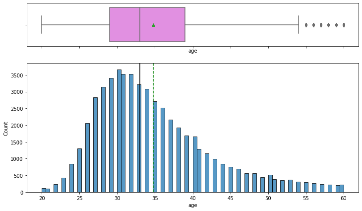

```python
histogram_boxplot(fileData, "age")
```

## Observations on length_of_service

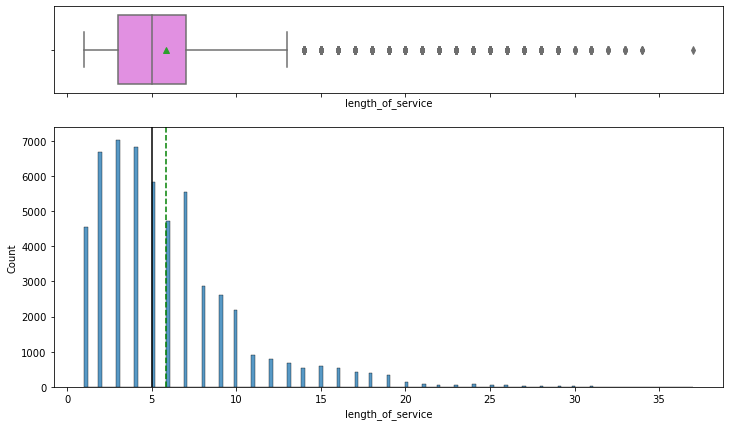

```python
histogram_boxplot(fileData, "length_of_service")
```

## Observations on no_of_trainings

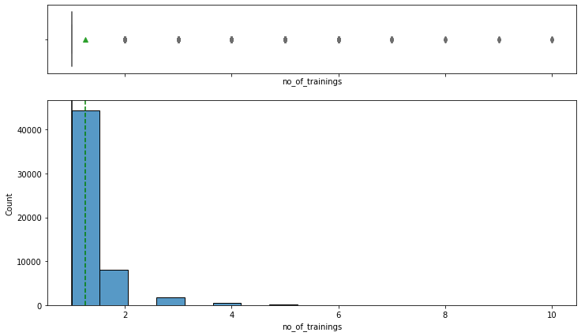

```python
histogram_boxplot(fileData, "no_of_trainings")
```

## Observations on awards_won

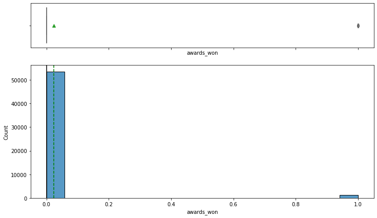

```python
histogram_boxplot(fileData, "awards_won")
```

## Observations on avg_training_score

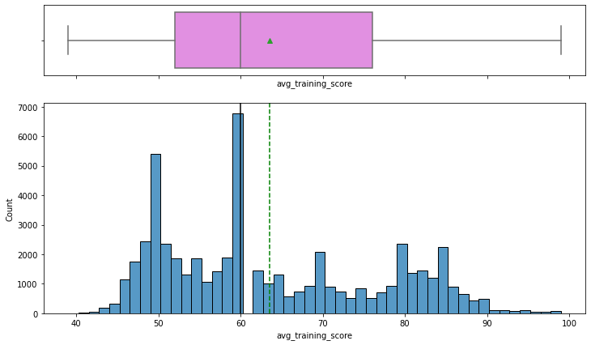

```python
histogram_boxplot(fileData, "avg_training_score")
```

## Observations on department

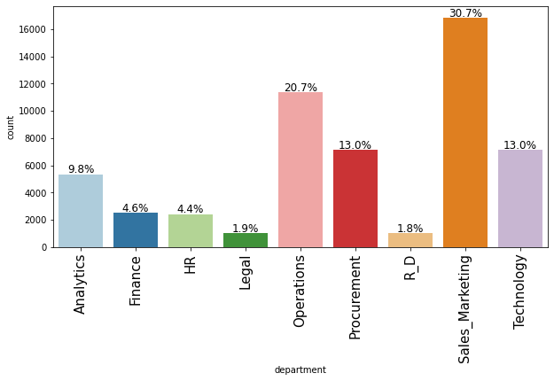

```python
labeled_barplot(fileData, "department", perc=True)
```

## Observations on education

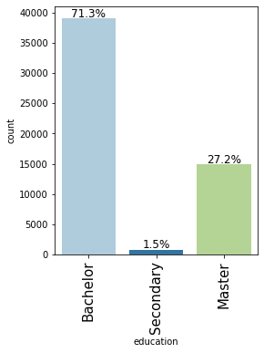

```python
labeled_barplot(fileData, "education", perc=True)
```

## Observations on recruitment_channel

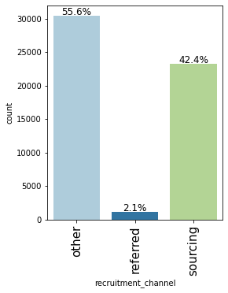

```python
labeled_barplot(fileData, "recruitment_channel", perc=True)
```

## Observations on gender

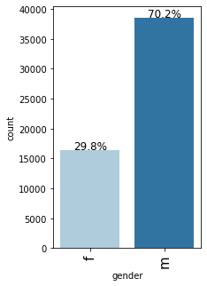

```python
labeled_barplot(fileData, "gender", perc=True)
```

## Observations on region

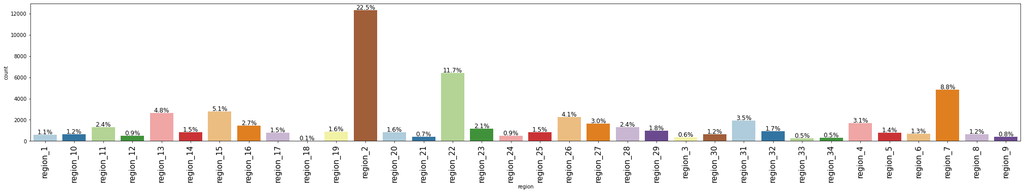

```python
labeled_barplot(fileData, "region", perc=True)
```

# Exploratory Data Analysis - Bivariate

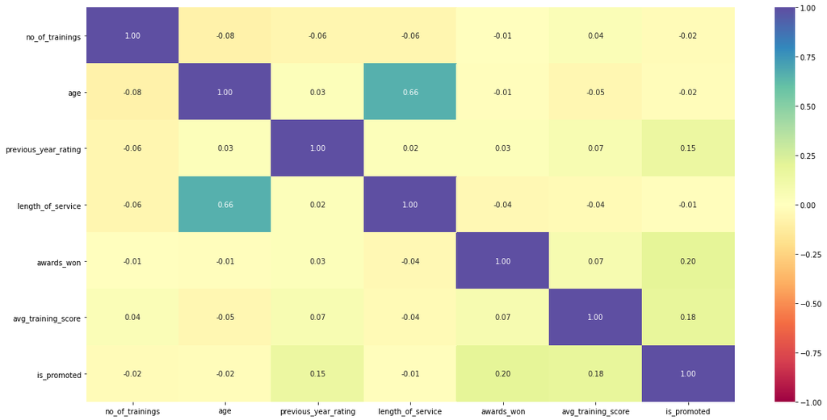

```python
plt.figure(figsize=(20, 10))
sns.heatmap(fileData.corr(), annot=True, vmin=-1, vmax=1, fmt=".2f", cmap="Spectral")
plt.show()
```

As shown above,

- length_of_service and age seem to be highly correlated
- is_promoted seems to be correlated with the awards_won
- is_promoted seems to be correlated with the previous_year_rating
- is_promoted seems to be correlated with the avg_training_score

```python
fileData.head()
```

|  | department | region | education | gender | recruitment_channel | no_of_trainings | age | previous_year_rating | length_of_service | awards_won | avg_training_score | is_promoted |
| --- | --- | --- | --- | --- | --- | --- | --- | --- | --- | --- | --- | --- |
| 0 | Sales_Marketing | region_7 | Master | f | sourcing | 1 | 35 | 5.0 | 8 | 0 | 49.0 | 0 |
| 1 | Operations | region_22 | Bachelor | m | other | 1 | 30 | 5.0 | 4 | 0 | 60.0 | 0 |
| 2 | Sales_Marketing | region_19 | Bachelor | m | sourcing | 1 | 34 | 3.0 | 7 | 0 | 50.0 | 0 |
| 3 | Sales_Marketing | region_23 | Bachelor | m | other | 2 | 39 | 1.0 | 10 | 0 | 50.0 | 0 |
| 4 | Technology | region_26 | Bachelor | m | other | 1 | 45 | 3.0 | 2 | 0 | 73.0 | 0 |

## is_promoted vs length_of_service and age

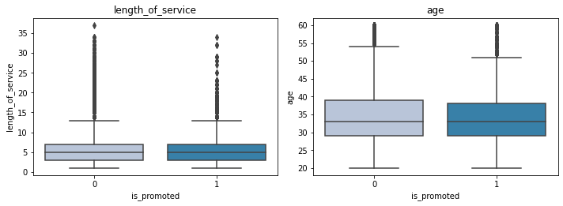

```python
cols = fileData[["length_of_service", "age"]].columns.tolist()
plt.figure(figsize=(10, 10))

for i, variable in enumerate(cols):
    plt.subplot(3, 2, i + 1)
    sns.boxplot(fileData["is_promoted"], fileData[variable], palette="PuBu")
    plt.tight_layout()
    plt.title(variable)
plt.show()
```

## is_promoted vs awards_won and previous_year_rating

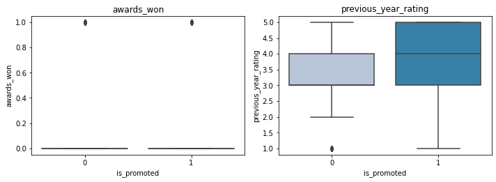

```python
cols = fileData[["awards_won", "previous_year_rating"]].columns.tolist()
plt.figure(figsize=(10, 10))

for i, variable in enumerate(cols):
    plt.subplot(3, 2, i + 1)
    sns.boxplot(fileData["is_promoted"], fileData[variable], palette="PuBu")
    plt.tight_layout()
    plt.title(variable)
plt.show()
```

## is_promoted vs avg_training_score and no_of_trainings

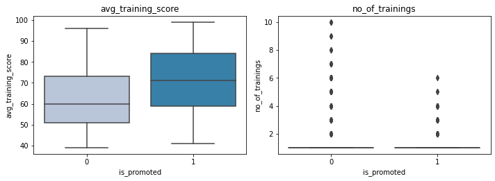

```python
cols = fileData[["avg_training_score", "no_of_trainings"]].columns.tolist()
plt.figure(figsize=(10, 10))

for i, variable in enumerate(cols):
    plt.subplot(3, 2, i + 1)
    sns.boxplot(fileData["is_promoted"], fileData[variable], palette="PuBu")
    plt.tight_layout()
    plt.title(variable)
plt.show()
```

## is_promoted vs gender and education

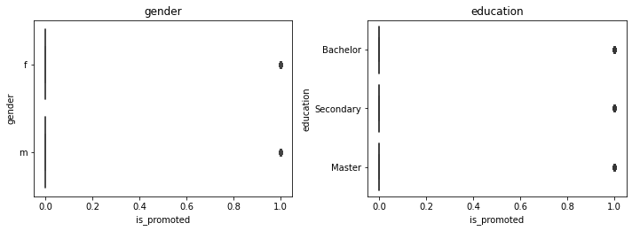

```python
cols = fileData[["gender", "education"]].columns.tolist()
plt.figure(figsize=(10, 10))

for i, variable in enumerate(cols):
    plt.subplot(3, 2, i + 1)
    sns.boxplot(fileData["is_promoted"], fileData[variable], palette="PuBu")
    plt.tight_layout()
    plt.title(variable)
plt.show()
```

## is_promoted based on gender

```
is_promoted      0     1    All
gender
All          50140  4668  54808
m            35295  3201  38496
f            14845  1467  16312
------------------------------------------------------------------------------------------------------------------------
```

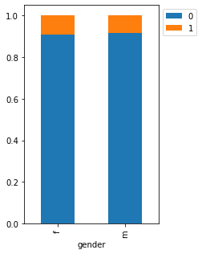

```python
stacked_barplot(fileData, "gender", "is_promoted")
```

## is_promoted based on education

```
is_promoted      0     1    All
education
All          50140  4668  54808
Bachelor     35948  3130  39078
Master       13454  1471  14925
Secondary      738    67    805
------------------------------------------------------------------------------------------------------------------------
```

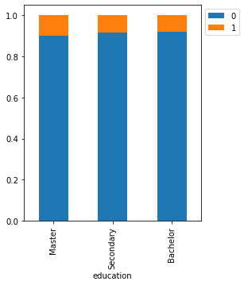

```python
stacked_barplot(fileData, "education", "is_promoted")
```

## is_promoted based on awards_won

```
is_promoted      0     1    All
awards_won
All          50140  4668  54808
0            49429  4109  53538
1              711   559   1270
------------------------------------------------------------------------------------------------------------------------
```

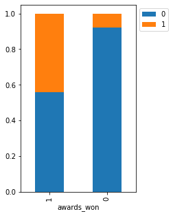

```python
stacked_barplot(fileData, "awards_won", "is_promoted")
```

## is_promoted based on department

```
is_promoted          0     1    All
department
All              50140  4668  54808
Sales_Marketing  15627  1213  16840
Operations       10325  1023  11348
Technology        6370   768   7138
Procurement       6450   688   7138
Analytics         4840   512   5352
Finance           2330   206   2536
HR                2282   136   2418
R_D                930    69    999
Legal              986    53   1039
------------------------------------------------------------------------------------------------------------------------
```

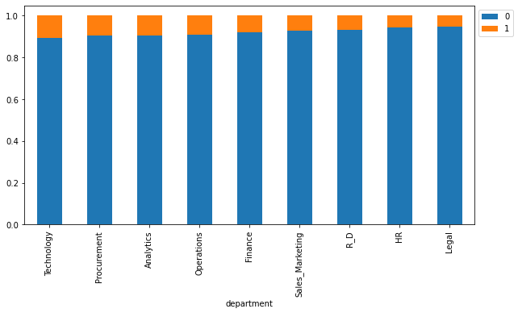

```python
stacked_barplot(fileData, "department", "is_promoted")
```

## is_promoted based on recruitment_channel

```
is_promoted              0     1    All
recruitment_channel
All                  50140  4668  54808
other                27890  2556  30446
sourcing             21246  1974  23220
referred              1004   138   1142
------------------------------------------------------------------------------------------------------------------------
```

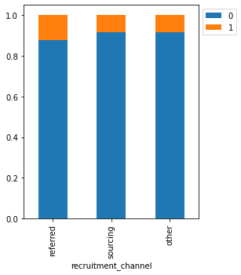

```python
stacked_barplot(fileData, "recruitment_channel", "is_promoted")
```

## Create Dummy Variables

```python
# creating dummy variables
fileData = pd.get_dummies(
    fileData,
    columns=fileData.select_dtypes(include=["object", "category"]).columns.tolist(),
    drop_first=False,
)
```

```python
fileData.info()
```

```
<class 'pandas.core.frame.DataFrame'>
RangeIndex: 54808 entries, 0 to 54807
Data columns (total 58 columns):
 #   Column                        Non-Null Count  Dtype
---  ------                        --------------  -----
 0   no_of_trainings               54808 non-null  int64
 1   age                           54808 non-null  int64
 2   previous_year_rating          54808 non-null  float64
 3   length_of_service             54808 non-null  int64
 4   awards_won                    54808 non-null  int64
 5   avg_training_score            54808 non-null  float64
 6   is_promoted                   54808 non-null  int64
 7   department_Analytics          54808 non-null  uint8
 8   department_Finance            54808 non-null  uint8
 9   department_HR                 54808 non-null  uint8
```

[output cut: 50 more lines]

## Let's create some predefined methods for evaluating models

```python
# defining a function to compute different metrics to check performance of a classification model built using sklearn
def model_performance_classification_sklearn(model, predictors, target):
    """
    Function to compute different metrics to check classification model performance

    model: classifier
    predictors: independent variables
    target: dependent variable
    """

    # predicting using the independent variables
    pred = model.predict(predictors)

    acc = accuracy_score(target, pred)  # to compute Accuracy
    recall = recall_score(target, pred)  # to compute Recall
    precision = precision_score(target, pred)  # to compute Precision
    f1 = f1_score(target, pred)  # to compute F1-score

    # creating a dataframe of metrics
    df_perf = pd.DataFrame(
        {"Accuracy": acc, "Recall": recall, "Precision": precision, "F1": f1,},
        index=[0],
    )

    return df_perf
```

```python
def confusion_matrix_sklearn(model, predictors, target):
    """
      To plot the confusion_matrix with percentages

      model: classifier
      predictors: independent variables
      target: dependent variable
      """
    y_pred = model.predict(predictors)
    cm = confusion_matrix(target, y_pred)
    labels = np.asarray(
        [
            ["{0:0.0f}".format(item) + "\n{0:.2%}".format(item / cm.flatten().sum())]
            for item in cm.flatten()
        ]
    ).reshape(2, 2)

    plt.figure(figsize=(6, 4))
    sns.heatmap(cm, annot=labels, fmt="")
    plt.ylabel("True label")
    plt.xlabel("Predicted label")
```

```python
## Function to create confusion matrix
def make_confusion_matrix(model, y_actual, labels=[1, 0]):
    """
    model : classifier to predict values of X
    y_actual : ground truth

    """
    y_predict = model.predict(X_test)
    cm = metrics.confusion_matrix(y_actual, y_predict, labels=[0, 1])
    df_cm = pd.DataFrame(
        cm,
        index=[i for i in ["Actual - No", "Actual - Yes"]],
        columns=[i for i in ["Predicted - No", "Predicted - Yes"]],
    )
    group_counts = ["{0:0.0f}".format(value) for value in cm.flatten()]
    group_percentages = ["{0:.2%}".format(value) for value in cm.flatten() / np.sum(cm)]
    labels = [f"{v1}\n{v2}" for v1, v2 in zip(group_counts, group_percentages)]
    labels = np.asarray(labels).reshape(2, 2)
    plt.figure(figsize=(10, 7))
    sns.heatmap(df_cm, annot=labels, fmt="")
    plt.ylabel("True label")
    plt.xlabel("Predicted label")
```

```python
## Function to create confusion matrix
def make_confusion_matrix(model, y_actual, labels=[1, 0]):
    """
    model : classifier to predict values of X
    y_actual : ground truth

    """
    y_predict = model.predict(X_test)
    cm = metrics.confusion_matrix(y_actual, y_predict, labels=[0, 1])
    df_cm = pd.DataFrame(
        cm,
        index=[i for i in ["Actual - No", "Actual - Yes"]],
        columns=[i for i in ["Predicted - No", "Predicted - Yes"]],
    )
    group_counts = ["{0:0.0f}".format(value) for value in cm.flatten()]
    group_percentages = ["{0:.2%}".format(value) for value in cm.flatten() / np.sum(cm)]
    labels = [f"{v1}\n{v2}" for v1, v2 in zip(group_counts, group_percentages)]
    labels = np.asarray(labels).reshape(2, 2)
    plt.figure(figsize=(10, 7))
    sns.heatmap(df_cm, annot=labels, fmt="")
    plt.ylabel("True label")
    plt.xlabel("Predicted label")
```

## Split the data into train, validation and test sets

```python
x = fileData.drop(["is_promoted"], axis=1)
y = fileData["is_promoted"]
```

```python
x.head()
```

|  | no_of_trainings | age | previous_year_rating | length_of_service | awards_won | avg_training_score | department_Analytics | department_Finance | department_HR | department_Legal | ... | region_region_8 | region_region_9 | education_Bachelor | education_Secondary | education_Master | gender_f | gender_m | recruitment_channel_other | recruitment_channel_referred | recruitment_channel_sourcing |
| --- | --- | --- | --- | --- | --- | --- | --- | --- | --- | --- | --- | --- | --- | --- | --- | --- | --- | --- | --- | --- | --- |
| 0 | 1 | 35 | 5.0 | 8 | 0 | 49.0 | 0 | 0 | 0 | 0 | ... | 0 | 0 | 0 | 0 | 1 | 1 | 0 | 0 | 0 | 1 |
| 1 | 1 | 30 | 5.0 | 4 | 0 | 60.0 | 0 | 0 | 0 | 0 | ... | 0 | 0 | 1 | 0 | 0 | 0 | 1 | 1 | 0 | 0 |
| 2 | 1 | 34 | 3.0 | 7 | 0 | 50.0 | 0 | 0 | 0 | 0 | ... | 0 | 0 | 1 | 0 | 0 | 0 | 1 | 0 | 0 | 1 |
| 3 | 2 | 39 | 1.0 | 10 | 0 | 50.0 | 0 | 0 | 0 | 0 | ... | 0 | 0 | 1 | 0 | 0 | 0 | 1 | 1 | 0 | 0 |
| 4 | 1 | 45 | 3.0 | 2 | 0 | 73.0 | 0 | 0 | 0 | 0 | ... | 0 | 0 | 1 | 0 | 0 | 0 | 1 | 1 | 0 | 0 |

5 rows × 57 columns

```python
y.head()
```

```
0    0
1    0
2    0
3    0
4    0
Name: is_promoted, dtype: int64
```

```python
# Splitting data into training, validation and test set:
# first we split data into 2 parts, say temporary and test

X_temp, X_test, y_temp, y_test = train_test_split(
    x, y, test_size=0.2, random_state=1, stratify=y
)

# then we split the temporary set into train and validation

X_train, X_val, y_train, y_val = train_test_split(
    X_temp, y_temp, test_size=0.25, random_state=1, stratify=y_temp
)
print(X_train.shape, X_val.shape, X_test.shape)
```

```
(32884, 57) (10962, 57) (10962, 57)
```

## Building the model

### Model with original data

```python
models = []  # Empty list to store all the models

# Appending models into the list
models.append(("Logistic regression", LogisticRegression(random_state=1)))
models.append(("Bagging", BaggingClassifier(random_state=1)))
models.append(("Random forest", RandomForestClassifier(random_state=1)))
models.append(("GBM", GradientBoostingClassifier(random_state=1)))
models.append(("Adaboost", AdaBoostClassifier(random_state=1)))
models.append(("Xgboost", XGBClassifier(random_state=1, eval_metric="logloss")))
models.append(("dtree", DecisionTreeClassifier(random_state=1)))

results1 = []  # Empty list to store all model's CV scores
names = []  # Empty list to store name of the models


# loop through all models to get the mean cross validated score
print("\n" "Cross-Validation Performance:" "\n")

for name, model in models:
    scoring = "recall"
    kfold = StratifiedKFold(
        n_splits=5, shuffle=True, random_state=1
    )  # Setting number of splits equal to 5
    cv_result = cross_val_score(
        estimator=model, X=X_train, y=y_train, scoring=scoring, cv=kfold
    )
    results1.append(cv_result)
    names.append(name)
    print("{}: {}".format(name, cv_result.mean() * 100))

print("\n" "Validation Performance:" "\n")

for name, model in models:
    model.fit(X_train, y_train)
    scores = recall_score(y_val, model.predict(X_val))
    print("{}: {}".format(name, scores))
```

```
Cross-Validation Performance:

Logistic regression: 16.964285714285715
Bagging: 32.285714285714285
Random forest: 22.46428571428572
GBM: 27.500000000000004
Adaboost: 17.535714285714285
Xgboost: 32.39285714285714
dtree: 39.07142857142857

Validation Performance:

Logistic regression: 0.1809421841541756
Bagging: 0.33083511777301927
Random forest: 0.24197002141327623
GBM: 0.27944325481798715
Adaboost: 0.16809421841541755
Xgboost: 0.32012847965738755
dtree: 0.39828693790149894
```

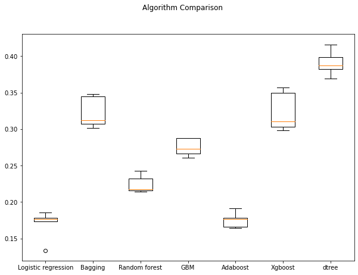

```python
# Plotting boxplots for CV scores of all models defined above
fig = plt.figure(figsize=(10, 7))

fig.suptitle("Algorithm Comparison")
ax = fig.add_subplot(111)

plt.boxplot(results1)
ax.set_xticklabels(names)

plt.show()
```

## Findings

- Dtree seems to be the best compared to others
- Xgboost seems to be the next one along with Bagging

## Models with Oversampled Data

```python
print("Before Oversampling, counts of label 'Yes': {}".format(sum(y_train == 1)))
print("Before Oversampling, counts of label 'No': {} \n".format(sum(y_train == 0)))

sm = SMOTE(
    sampling_strategy=1, k_neighbors=5, random_state=1
)  # Synthetic Minority Over Sampling Technique
X_train_over, y_train_over = sm.fit_resample(X_train, y_train)


print("After Oversampling, counts of label 'Yes': {}".format(sum(y_train_over == 1)))
print("After Oversampling, counts of label 'No': {} \n".format(sum(y_train_over == 0)))


print("After Oversampling, the shape of train_X: {}".format(X_train_over.shape))
print("After Oversampling, the shape of train_y: {} \n".format(y_train_over.shape))
```

```
Before Oversampling, counts of label 'Yes': 2800
Before Oversampling, counts of label 'No': 30084

After Oversampling, counts of label 'Yes': 30084
After Oversampling, counts of label 'No': 30084

After Oversampling, the shape of train_X: (60168, 57)
After Oversampling, the shape of train_y: (60168,)
```

```python
models = []  # Empty list to store all the models

# Appending models into the list
models.append(("Logistic regression", LogisticRegression(random_state=1)))
models.append(("Bagging", BaggingClassifier(random_state=1)))
models.append(("Random forest", RandomForestClassifier(random_state=1)))
models.append(("GBM", GradientBoostingClassifier(random_state=1)))
models.append(("Adaboost", AdaBoostClassifier(random_state=1)))
models.append(("Xgboost", XGBClassifier(random_state=1, eval_metric="logloss")))
models.append(("dtree", DecisionTreeClassifier(random_state=1)))

results2 = []  # Empty list to store all model's CV scores
names = []  # Empty list to store name of the models


# loop through all models to get the mean cross validated score
print("\n" "Cross-Validation Performance:" "\n")

for name, model in models:
    scoring = "recall"
    kfold = StratifiedKFold(
        n_splits=5, shuffle=True, random_state=1
    )  # Setting number of splits equal to 5
    cv_result = cross_val_score(
        estimator=model, X=X_train_over, y=y_train_over, scoring=scoring, cv=kfold
    )
    results2.append(cv_result)
    names.append(name)
    print("{}: {}".format(name, cv_result.mean() * 100))

print("\n" "Validation Performance:" "\n")

for name, model in models:
    model.fit(X_train_over, y_train_over)
    scores = recall_score(y_val, model.predict(X_val))
    print("{}: {}".format(name, scores))
```

```
Cross-Validation Performance:

Logistic regression: 86.0258511787524
Bagging: 93.70430279102825
Random forest: 93.66440862149442
GBM: 87.3421101427162
Adaboost: 86.25516930752937
Xgboost: 92.87660195492205
dtree: 94.1430657242423

Validation Performance:

Logistic regression: 0.35974304068522484
Bagging: 0.3019271948608137
Random forest: 0.2494646680942184
GBM: 0.32441113490364026
Adaboost: 0.32012847965738755
Xgboost: 0.3158458244111349
dtree: 0.354389721627409
```

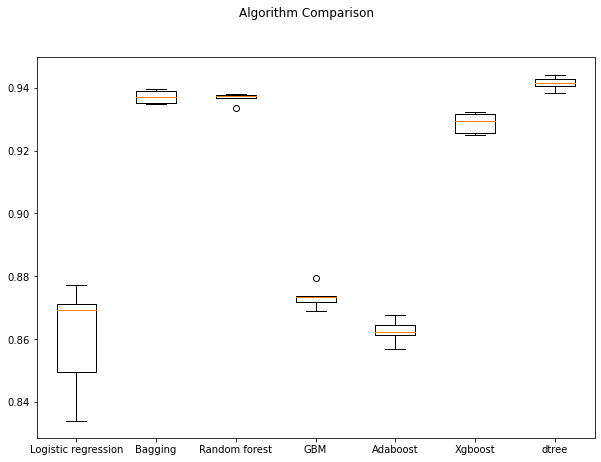

```python
# Plotting boxplots for CV scores of all models defined above
fig = plt.figure(figsize=(10, 7))

fig.suptitle("Algorithm Comparison")
ax = fig.add_subplot(111)

plt.boxplot(results2)
ax.set_xticklabels(names)

plt.show()
```

## Findings

- Dtree seems to be the best model compared to others
- Bagging and RandomForest also seem to be better with Xgboost coming near